## Assignment - Prediction Assignment Writeup report

### 1. Data import and selection of predictors

The first part of this report describes selection of predictor variables for use during model construction. Reducing the number of predictor variables is an important step in order to remove random noise in the dataset. Several different strategies for reducing number of features exists. Below follows an explanation of the strategy used in this assignment.

The training dataset for the assignment was obtained from the following url: https://d396qusza40orc.cloudfront.net/predmachlearn/pml-training.csv. Data was downloaded and imported into R studio using the following code:

```r
  url1<- "https://d396qusza40orc.cloudfront.net/predmachlearn/pml-training.csv"
    download.file(url1,destfile="./trainset.csv")
    training = read.csv("trainset.csv", header=T, na.strings = c("NA","", " ","#DIV/0!") )
    url2<- "https://d396qusza40orc.cloudfront.net/predmachlearn/pml-testing.csv "
    download.file(url2,destfile="./validationset.csv")
    testing = read.csv("validationset.csv",header=T, na.strings = c("NA","", " ","#DIV/0!") )
```

The trainingdata is a matrix comprising 19622 observations of 160 variables. The first step to select important predictor variables was to remove predictors that did not contain any values, i.e. the columns containing the NA values. The following code was used to remove predictors containing more than one NA value:

```r
  RemovedNATrain <-which(colSums(is.na(training))>1)
    training1 <-training[,-c(RemovedNATrain)]
    dim(training1)
```

```
## [1] 19622    60
```

A total of 100 predictors were removed. The new data matrix comprised 19622 observations of 60 variables. Next step in predictor selection involved manual inspection of the predictors. The first seven predictors contained annotation information, hence likely not related to the predicted outcome. These were removed using the following code:

```r
training2 <- subset( training1, select = -c( X : num_window ))
```

The new data matrix comprised 19622 observations of 53 variables. Next step involved identification of near zero variance predictors, since these would most certainly not be useful covariates:

```r
library(caret)
TestNearZero <- nearZeroVar(training2[sapply(training2,is.numeric)],saveMetrics = TRUE)
nzv(training2, freqCut = 95/5, uniqueCut = 10, saveMetrics = FALSE, names = FALSE)
```

```
## integer(0)
```

```r
TestNearZero
```

```
##                      freqRatio percentUnique zeroVar   nzv
## roll_belt             1.101904     6.7781062   FALSE FALSE
## pitch_belt            1.036082     9.3772296   FALSE FALSE
## yaw_belt              1.058480     9.9734991   FALSE FALSE
## total_accel_belt      1.063160     0.1477933   FALSE FALSE
## gyros_belt_x          1.058651     0.7134849   FALSE FALSE
## gyros_belt_y          1.144000     0.3516461   FALSE FALSE
## gyros_belt_z          1.066214     0.8612782   FALSE FALSE
## accel_belt_x          1.055412     0.8357966   FALSE FALSE
## accel_belt_y          1.113725     0.7287738   FALSE FALSE
## accel_belt_z          1.078767     1.5237998   FALSE FALSE
## magnet_belt_x         1.090141     1.6664968   FALSE FALSE
## magnet_belt_y         1.099688     1.5187035   FALSE FALSE
## magnet_belt_z         1.006369     2.3290184   FALSE FALSE
## roll_arm             52.338462    13.5256345   FALSE FALSE
## pitch_arm            87.256410    15.7323412   FALSE FALSE
## yaw_arm              33.029126    14.6570176   FALSE FALSE
## total_accel_arm       1.024526     0.3363572   FALSE FALSE
## gyros_arm_x           1.015504     3.2769341   FALSE FALSE
## gyros_arm_y           1.454369     1.9162165   FALSE FALSE
## gyros_arm_z           1.110687     1.2638875   FALSE FALSE
## accel_arm_x           1.017341     3.9598410   FALSE FALSE
## accel_arm_y           1.140187     2.7367241   FALSE FALSE
## accel_arm_z           1.128000     4.0362858   FALSE FALSE
## magnet_arm_x          1.000000     6.8239731   FALSE FALSE
## magnet_arm_y          1.056818     4.4439914   FALSE FALSE
## magnet_arm_z          1.036364     6.4468454   FALSE FALSE
## roll_dumbbell         1.022388    84.2065029   FALSE FALSE
## pitch_dumbbell        2.277372    81.7449801   FALSE FALSE
## yaw_dumbbell          1.132231    83.4828254   FALSE FALSE
## total_accel_dumbbell  1.072634     0.2191418   FALSE FALSE
## gyros_dumbbell_x      1.003268     1.2282132   FALSE FALSE
## gyros_dumbbell_y      1.264957     1.4167771   FALSE FALSE
## gyros_dumbbell_z      1.060100     1.0498420   FALSE FALSE
## accel_dumbbell_x      1.018018     2.1659362   FALSE FALSE
## accel_dumbbell_y      1.053061     2.3748853   FALSE FALSE
## accel_dumbbell_z      1.133333     2.0894914   FALSE FALSE
## magnet_dumbbell_x     1.098266     5.7486495   FALSE FALSE
## magnet_dumbbell_y     1.197740     4.3012945   FALSE FALSE
## magnet_dumbbell_z     1.020833     3.4451126   FALSE FALSE
## roll_forearm         11.589286    11.0895933   FALSE FALSE
## pitch_forearm        65.983051    14.8557741   FALSE FALSE
## yaw_forearm          15.322835    10.1467740   FALSE FALSE
## total_accel_forearm   1.128928     0.3567424   FALSE FALSE
## gyros_forearm_x       1.059273     1.5187035   FALSE FALSE
## gyros_forearm_y       1.036554     3.7763735   FALSE FALSE
## gyros_forearm_z       1.122917     1.5645704   FALSE FALSE
## accel_forearm_x       1.126437     4.0464784   FALSE FALSE
## accel_forearm_y       1.059406     5.1116094   FALSE FALSE
## accel_forearm_z       1.006250     2.9558659   FALSE FALSE
## magnet_forearm_x      1.012346     7.7667924   FALSE FALSE
## magnet_forearm_y      1.246914     9.5403119   FALSE FALSE
## magnet_forearm_z      1.000000     8.5771073   FALSE FALSE
```

No samples were removed, all samples had enough variability. Next step was to remove highly correlated numerical features. This were used by first generating a correlation matrix and then use the findCorrelation function within the caret package to remove highly correlated predictors:

```r
CorMat <-abs(cor(training2[sapply(training2, is.numeric)]))
r = findCorrelation(CorMat, cutoff = .90, verbose = TRUE)
```

```
## Compare row 10  and column  1 with corr  0.992
##   Means:  0.27 vs 0.168 so flagging column 10
## Compare row 1  and column  9 with corr  0.925
##   Means:  0.25 vs 0.164 so flagging column 1
## Compare row 9  and column  4 with corr  0.928
##   Means:  0.233 vs 0.161 so flagging column 9
## Compare row 8  and column  2 with corr  0.966
##   Means:  0.245 vs 0.157 so flagging column 8
## Compare row 19  and column  18 with corr  0.918
##   Means:  0.091 vs 0.158 so flagging column 18
## Compare row 46  and column  31 with corr  0.914
##   Means:  0.101 vs 0.161 so flagging column 31
## Compare row 46  and column  33 with corr  0.933
##   Means:  0.083 vs 0.164 so flagging column 33
## All correlations <= 0.9
```

```r
training3 = training2[,-r]
```

### 2. Construction and optimization of prediction model

The second part of this report describes construction of the predictive model. In order to achieve accurate predictions of unknown samples, it is important to tune and optimize parameters on a selected model. It is important that all such optimization steps are performed only on samples in training data in order not to risk overfitting when generalizing to new samples. In order to tune our model and to estimate model performance, we split the trainingdata into two fractions: a training fraction (75% of samples) containing the samples used to train the model and to estimate the tuning parameters, and a test set (25% of samples) to evaluate the ability of our model to generalize to unseen samples.

```r
set.seed(2)
train <-createDataPartition(y=training3$classe,p=0.75,list=FALSE)
trainset<-training3[train,]
testset<-training3[-train,]
dim(trainset)
```

```
## [1] 14718    46
```

```r
dim(testset)
```

```
## [1] 4904   46
```

Since the variable that should be predicted in this assignment comprised five groups, binary classification models such as SVMs could not be considered. Due to personal preferences, a Random Forest (RF) model was first fitted to the samples in the trainingset. The only available tuning parameter was mtry, the number of variables randomly sampled as candidates at each split.

```r
library(randomForest)
set.seed(2)
ctrl = trainControl(method = "cv",number=3, allowParallel=T)
rf.caret.model = train(classe~., data=trainset, method="rf",trControl=ctrl, tuneGrid=expand.grid(.mtry=1:7),verbose=FALSE)
rf.caret.model
```

```
## Random Forest
##
## 14718 samples
##    45 predictor
##     5 classes: 'A', 'B', 'C', 'D', 'E'
##
## No pre-processing
## Resampling: Cross-Validated (3 fold)
## Summary of sample sizes: 9812, 9812, 9812
## Resampling results across tuning parameters:
##
##   mtry  Accuracy   Kappa      Accuracy SD   Kappa SD
##   1     0.9816551  0.9767857  0.0006114961  0.000771878
##   2     0.9878380  0.9846135  0.0019797258  0.002505088
##   3     0.9896046  0.9868497  0.0013366161  0.001691749
##   4     0.9900122  0.9873657  0.0015388982  0.001946648
##   5     0.9913032  0.9889991  0.0013874560  0.001754146
##   6     0.9914391  0.9891708  0.0008153282  0.001029852
##   7     0.9908955  0.9884833  0.0013571806  0.001716210
##
## Accuracy was used to select the optimal model using  the largest value.
## The final value used for the model was mtry = 6.
```

```r
rf.caret.model$finalModel
```

```
##
## Call:
##  randomForest(x = x, y = y, mtry = param$mtry, verbose = FALSE)
##                Type of random forest: classification
##                      Number of trees: 500
## No. of variables tried at each split: 6
##
##         OOB estimate of  error rate: 0.52%
## Confusion matrix:
##      A    B    C    D    E  class.error
## A 4181    3    0    0    1 0.0009557945
## B   13 2830    5    0    0 0.0063202247
## C    0   15 2550    2    0 0.0066225166
## D    0    0   30 2380    2 0.0132669983
## E    0    0    2    4 2700 0.0022172949
```

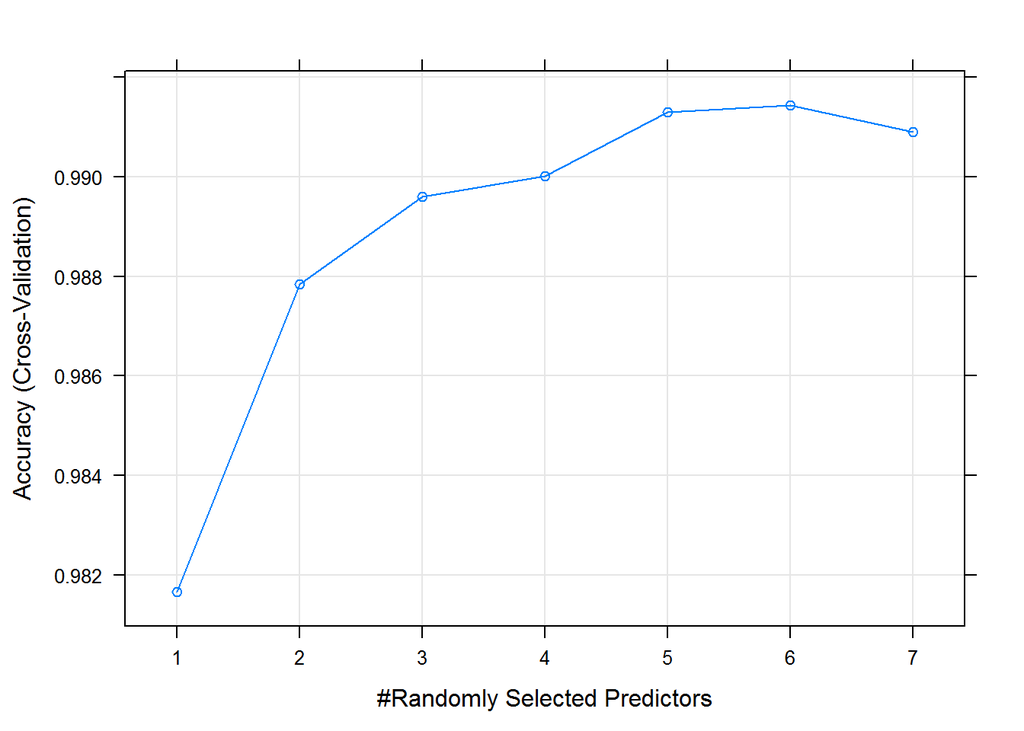

```r
plot(rf.caret.model)
```

We can also chech the most important variables in case we need to reduce number of predictors:

```r
varImp(rf.caret.model)
```

```
## rf variable importance
##
##   only 20 most important variables shown (out of 45)
##
##                      Overall
## yaw_belt              100.00
## magnet_dumbbell_z      73.47
## pitch_belt             71.39
## pitch_forearm          69.27
## magnet_dumbbell_y      59.52
## roll_forearm           54.44
## magnet_belt_y          48.34
## magnet_belt_z          46.23
## magnet_dumbbell_x      44.95
## accel_dumbbell_y       37.38
## roll_dumbbell          34.46
## gyros_belt_z           34.37
## accel_dumbbell_z       28.94
## roll_arm               28.56
## accel_forearm_x        26.36
## total_accel_belt       25.90
## magnet_forearm_z       23.39
## total_accel_dumbbell   21.94
## magnet_belt_x          21.62
## accel_forearm_z        21.02
```

### 3.) Results - Prediction of samples in test set

Samples in the testset set were predicted using the tuned model.

```r
pred1 = predict(rf.caret.model, newdata=testset)
confusionMatrix(pred1, testset$classe)
```

```
## Confusion Matrix and Statistics
##
##           Reference
## Prediction    A    B    C    D    E
##          A 1395    8    0    0    0
##          B    0  940    6    0    0
##          C    0    1  849    5    0
##          D    0    0    0  797    1
##          E    0    0    0    2  900
##
## Overall Statistics
##
##                Accuracy : 0.9953
##                  95% CI : (0.993, 0.997)
##     No Information Rate : 0.2845
##     P-Value [Acc > NIR] : < 2.2e-16
##
##                   Kappa : 0.9941
##  Mcnemar's Test P-Value : NA
##
## Statistics by Class:
##
##                      Class: A Class: B Class: C Class: D Class: E
## Sensitivity            1.0000   0.9905   0.9930   0.9913   0.9989
## Specificity            0.9977   0.9985   0.9985   0.9998   0.9995
## Pos Pred Value         0.9943   0.9937   0.9930   0.9987   0.9978
## Neg Pred Value         1.0000   0.9977   0.9985   0.9983   0.9998
## Prevalence             0.2845   0.1935   0.1743   0.1639   0.1837
## Detection Rate         0.2845   0.1917   0.1731   0.1625   0.1835
## Detection Prevalence   0.2861   0.1929   0.1743   0.1627   0.1839
## Balanced Accuracy      0.9989   0.9945   0.9958   0.9955   0.9992
```

For prediction of samples in the left out test set, the model reached an impressive accuracy of 99.5%. This means that we do not need to optimize model or try other models. Since compounds in left out test set was not used during model construction or optimization, the accuracy is a valid estimate of the out of sample accuracy.

### 4.) Results - Prediction of samples in independent validationset

Samples in the independent test set were predicted with the same model:

```r
Finaltest<-testing[,names(training3[,-46])]
dim(Finaltest)
```

```
## [1] 20 45
```

```r
pred2 = predict(rf.caret.model, newdata=Finaltest)
```

These answers were submitted to Coursera